# HW7 Instructions

Data Science for Biologists, Fall 2020

R script due Friday 10/30/20 by 11:59 PM to Canvas

## Instructions

For your assignment, you will be practicing data tidying skills with `tidyr` using several different datasets, many of which stored in the directory `hw7_datasets/`.

Please read these additional instructions carefully:

- **ALWAYS RUN AND CHECK CODE ONE LINE AT A TIME!!!**
- Any answers without corresponding code will receive no credit.
- All plots must be professionally labeled with clean X and Y axes. You are not required to include a title, subtitle, or caption, but you may include one or more of these labels if you choose.
- All plots using aesthetic color/fill mappings *MUST USE* a non-default color scale. Similarly, all legend titles must be professionally re-named from their default.
- When applicable, all saved plots must be clearly legible with an appropriate aspect ratio. This means you may need to change the output plot size using arguments `width` and `height` when calling `ggsave()`. *Make extra sure to LOOK AT YOUR SAVED PLOTS* and tweak the size until it looks clearly professional.
  - You may also need to modify certain theme components to achieve a professional look!
- Ask me for help AT LEAST 24 hours before the deadline. I cannot guarantee time to help you if only short notice is given. Given my schedule, I can probably (unfortunately) guarantee that I won’t have time to help.
- Write all code yourself and include COMMENTS for each plot you create.
- Please *comment out* (add `#` in front of) code that causes errors or bugs. This will ensure that your code runs without errors, while also showing me your code attempt if you only got part-way through recreating the plot.

## Questions

> All questions should be answered in the provided hw7.R script template.

## EXAMPLE DATA

This assignment contains many code demonstrations which use a *subsetted version of the `iris` dataset*. This subsetted version contains only NINE TOTAL ROWS, with three rows for each species. The code below shows how it was created as well as what it looks like:

```r
iris %>%
  group_by(Species) %>%
  # Add 1-50 for each species - you'll want to run this yourself to see! n() is a useful dplyr function itself that you'll learn about in this HW
  mutate(row_number = 1:n()) %>%
  # Only keep the first 3 observations per group
  filter(row_number <= 3) %>%
  # We're done with row_number, get rid of it
  select(-row_number) %>%
  # ungroup or else species grouping will remain!
  ungroup() -> iris9

# show iris9:
iris9
```

```
## # A tibble: 9 x 5
##   Sepal.Length Sepal.Width Petal.Length Petal.Width Species
##          <dbl>       <dbl>        <dbl>       <dbl> <fct>
## 1          5.1         3.5          1.4         0.2 setosa
## 2          4.9         3            1.4         0.2 setosa
## 3          4.7         3.2          1.3         0.2 setosa
## 4          7           3.2          4.7         1.4 versicolor
## 5          6.4         3.2          4.5         1.5 versicolor
## 6          6.9         3.1          4.9         1.5 versicolor
## 7          6.3         3.3          6           2.5 virginica
## 8          5.8         2.7          5.1         1.9 virginica
## 9          7.1         3            5.9         2.1 virginica
```

## Part 1: Fundamental pivoting

1.1. Consider the dataset `algae_co2_uptake.csv`. This dataset contains information about the mean CO2 uptake of algae from three locations exposed to nonchilled and chilled environments. Read in the dataset here, and use the function `pivot_longer()` to tidy the dataset so it looks like this. You should SAVE this dataset to be called `algae_long` (you will use it in the next question).

```
## # A tibble: 6 x 3
##   origin treatment  uptake
##   <chr>  <chr>       <dbl>
## 1 Canada nonchilled     36
## 2 Canada chilled        31
## 3 USA    nonchilled     33
## 4 USA    chilled        28
## 5 Mexico nonchilled     56
## 6 Mexico chilled        18
```

1.2. Write the code required to convert `algae_long` dataset BACK to its wide version using `pivot_wider()`. The resulting dataframe should look exactly like the original dataset read in from `algae_co2_uptake.csv`.

1.3. Consider the dataset called `plant_growth.csv`. This dataset shows crop yields (don’t worry about units) for a given plant under two treatments and a control. There are 10 plants, each of which was exposed to all experimental conditions.

This data is currently *tidy*. Make it messy using `pivot_wider()` to end up with a dataframe that looks like this:

```
## # A tibble: 10 x 4
##    plant_id  ctrl  trt1  trt2
##       <dbl> <dbl> <dbl> <dbl>
##  1        1  4.17  4.81  6.31
##  2        2  5.58  4.17  5.12
##  3        3  5.18  4.41  5.54
##  4        4  6.11  3.59  5.5
##  5        5  4.5   5.87  5.37
##  6        6  4.61  3.83  5.29
##  7        7  5.17  6.03  4.92
##  8        8  4.53  4.89  6.15
##  9        9  5.33  4.32  5.8
## 10       10  5.14  4.69  5.26
```

1.4. You’ll notice in the last question, the `plant_growth.csv` dataset has a column called `plant_id`. This column uniquely identifies each plant so that after we pivot, we can clearly tell which plant is which. To see how important this is, again use `pivot_wider()` on this dataset in the same way as the last question, but this time *first select OUT* the `plant_id` column (`select(-plant_id)`).

You will the output is very funky with a LOT of warnings. This main warning message describes the problem: *“Values are not uniquely identified; output will contain list-cols.”* Indeed, rows are NOT uniquely identified.

1.5. Let’s now learn how to solve this problem - what if we had a dataset that did not already contain a column to uniquely identify each plant or participant? We would have to *make one before pivoting*. The best way to accomplish this is to use mutate to create a column that contains a unique number. `dplyr` has a helper function `n()` which will provide the total number of observations in a group - if the data is ungrouped, it’s just the full number of rows. Run the example below to understand how `n()` works.

```r
iris9 %>%
  # Create a column `row_number` with values 1-9 (iris9 has 9 rows only)
  mutate(row_number = 1:n()) ## 1:n() makes an array, 1 - number of rows.
```

```
## # A tibble: 9 x 6
##   Sepal.Length Sepal.Width Petal.Length Petal.Width Species    row_number
##          <dbl>       <dbl>        <dbl>       <dbl> <fct>           <int>
## 1          5.1         3.5          1.4         0.2 setosa              1
## 2          4.9         3            1.4         0.2 setosa              2
## 3          4.7         3.2          1.3         0.2 setosa              3
## 4          7           3.2          4.7         1.4 versicolor          4
## 5          6.4         3.2          4.5         1.5 versicolor          5
## 6          6.9         3.1          4.9         1.5 versicolor          6
## 7          6.3         3.3          6           2.5 virginica           7
## 8          5.8         2.7          5.1         1.9 virginica           8
## 9          7.1         3            5.9         2.1 virginica           9
```

Then, practice using `n()` by taking these steps:

- Remove the `plant_id` column with `select()`
- *Re-create* the `plant_id` column with `mutate()` and `n()`
- Pivot as we have been doing to create the final wide version of the dataset

1.6. Use the built-in `msleep` dataset. Create a new version of the dataframe that looks like this:

> Hint: First use select to subset the data to only the columns you need, and then pivot.

```
## # A tibble: 166 x 3
##    name                       taxonomic_level group
##    <chr>                      <chr>           <chr>
##  1 Cheetah                    genus           Acinonyx
##  2 Cheetah                    order           Carnivora
##  3 Owl monkey                 genus           Aotus
##  4 Owl monkey                 order           Primates
##  5 Mountain beaver            genus           Aplodontia
##  6 Mountain beaver            order           Rodentia
##  7 Greater short-tailed shrew genus           Blarina
##  8 Greater short-tailed shrew order           Soricomorpha
##  9 Cow                        genus           Bos
## 10 Cow                        order           Artiodactyla
## # … with 156 more rows
```

1.7. Again use the built-in `msleep` dataset and create a new version that looks like this:

> Hint: There are no NA’s in my final version output! You should drop all NAs at the *end*.

```
## # A tibble: 139 x 3
##    name                       measurement    weight
##    <chr>                      <chr>           <dbl>
##  1 Cheetah                    bodywt       50
##  2 Owl monkey                 brainwt       0.0155
##  3 Owl monkey                 bodywt        0.48
##  4 Mountain beaver            bodywt        1.35
##  5 Greater short-tailed shrew brainwt       0.00029
##  6 Greater short-tailed shrew bodywt        0.019
##  7 Cow                        brainwt       0.423
##  8 Cow                        bodywt      600
##  9 Three-toed sloth           bodywt        3.85
## 10 Northern fur seal          bodywt       20.5
## # … with 129 more rows
```

1.8. Modify your code from the previous question so the final dataframe looks like this. You MUST use `rename()` as part of your code.

> Hint: Rename columns of interest first, and then pivot them.

> Hint 2: Again note the lack of NA’s!

```
## # A tibble: 139 x 3
##    name                       measurement    weight
##    <chr>                      <chr>           <dbl>
##  1 Cheetah                    body_mass    50
##  2 Owl monkey                 brain_mass    0.0155
##  3 Owl monkey                 body_mass     0.48
##  4 Mountain beaver            body_mass     1.35
##  5 Greater short-tailed shrew brain_mass    0.00029
##  6 Greater short-tailed shrew body_mass     0.019
##  7 Cow                        brain_mass    0.423
##  8 Cow                        body_mass   600
##  9 Three-toed sloth           body_mass     3.85
## 10 Northern fur seal          body_mass    20.5
## # … with 129 more rows
```

**Part 1 OPTIONAL BONUS**: For bonus points, create the same dataframe from the last question, but do NOT use `rename()`. Instead, use code that incorporates `mutate()` and `if_else()` to arrive at the final dataset version.

## Part 2: Practicing `tidy-select` magic

When pivoting, we often need to provide a bunch of columns. It is often easier to list these columns some `select()` magic. We have previously seen the magic of `everything()` (select *everything else*!). This magic actually comes to us from [tidy-select](https://dplyr.tidyverse.org/reference/dplyr_tidy_select.html), functionality in `dplyr` for cleanly specifying a set of columns.

For this set of questions, you will teach yourself some more magic by following examples and applying the concept to a new scenario. All examples use the subsetted `iris9` dataset created for these demos.

2.1. Use `starts_with()` to select all columns in `coffee_ratings` that start with the lowercase letter “b”.

```r
iris9 %>%
  # Keep only columns whose name starts with "Sepal"
  select(starts_with("Sepal"))
```

```
## # A tibble: 9 x 2
##   Sepal.Length Sepal.Width
##          <dbl>       <dbl>
## 1          5.1         3.5
## 2          4.9         3
## 3          4.7         3.2
## 4          7           3.2
## 5          6.4         3.2
## 6          6.9         3.1
## 7          6.3         3.3
## 8          5.8         2.7
## 9          7.1         3
```

2.2. Use `contains()` to select all columns in `coffee_ratings` that contain the word “altitude”.

```r
iris9 %>%
  # Keep only columns whose name contains the word "Length"
  select(contains("Length"))
```

```
## # A tibble: 9 x 2
##   Sepal.Length Petal.Length
##          <dbl>        <dbl>
## 1          5.1          1.4
## 2          4.9          1.4
## 3          4.7          1.3
## 4          7            4.7
## 5          6.4          4.5
## 6          6.9          4.9
## 7          6.3          6
## 8          5.8          5.1
## 9          7.1          5.9
```

2.3. You can use colons to specify a range of columns in order. Use colons to select all columns in `coffee_ratings` aroma through moisture.

```r
iris9 %>%
  # Keep columns Sepal.Length through Petal.Length
  select(Sepal.Length:Petal.Length)
```

```
## # A tibble: 9 x 3
##   Sepal.Length Sepal.Width Petal.Length
##          <dbl>       <dbl>        <dbl>
## 1          5.1         3.5          1.4
## 2          4.9         3            1.4
## 3          4.7         3.2          1.3
## 4          7           3.2          4.7
## 5          6.4         3.2          4.5
## 6          6.9         3.1          4.9
## 7          6.3         3.3          6
## 8          5.8         2.7          5.1
## 9          7.1         3            5.9
```

2.4. `last_col()` refers to the last column in a dataframe, in the order it appears. Select the last column only in `coffee_ratings`.

```r
iris9 %>%
  # Keep only the last column
  select(last_col())
```

```
## # A tibble: 9 x 1
##   Species
##   <fct>
## 1 setosa
## 2 setosa
## 3 setosa
## 4 versicolor
## 5 versicolor
## 6 versicolor
## 7 virginica
## 8 virginica
## 9 virginica
```

2.5. Combine your colon and `last_col()` skills to select all columns from aroma *through* the last column.

> Hint: Literally use `last_col()` on the right side of the colon!

2.6. `where()` uses a given function *but WITHOUT its normal parentheses*. Use `where()` to select all numeric columns in `coffee_ratings`. Several examples for how to use this function are shown:

```r
iris9 %>%
  # Keep columns where the column is a factor type
  select(where(is.factor))
```

```
## # A tibble: 9 x 1
##   Species
##   <fct>
## 1 setosa
## 2 setosa
## 3 setosa
## 4 versicolor
## 5 versicolor
## 6 versicolor
## 7 virginica
## 8 virginica
## 9 virginica
```

```r
iris9 %>%
  # Keep columns where the column is a numeric type
  select(where(is.numeric))
```

```
## # A tibble: 9 x 4
##   Sepal.Length Sepal.Width Petal.Length Petal.Width
##          <dbl>       <dbl>        <dbl>       <dbl>
## 1          5.1         3.5          1.4         0.2
## 2          4.9         3            1.4         0.2
## 3          4.7         3.2          1.3         0.2
## 4          7           3.2          4.7         1.4
## 5          6.4         3.2          4.5         1.5
## 6          6.9         3.1          4.9         1.5
## 7          6.3         3.3          6           2.5
## 8          5.8         2.7          5.1         1.9
## 9          7.1         3            5.9         2.1
```

```r
iris9 %>%
  # Keep columns where the column is a character type
  select(where(is.character))
```

```
## # A tibble: 9 x 0
```

```r
iris9 %>%
  # Keep columns where the column is a NOT a numeric type
  select(-where(is.numeric))
```

```
## # A tibble: 9 x 1
##   Species
##   <fct>
## 1 setosa
## 2 setosa
## 3 setosa
## 4 versicolor
## 5 versicolor
## 6 versicolor
## 7 virginica
## 8 virginica
## 9 virginica
```

2.7. Use `where()` to select all character columns in `coffee_ratings`.

2.8. Use `where()` to select all numeric columns in `coffee_ratings`.

2.9. Consider the dataset in `life_expectancy_years.csv`. This dataset was downloaded from the excellent resource [Gapminder](https://www.gapminder.org/data/), which contains *tons* of free and easily-download datasets about the world. This particular dataset shows life expectancy in years across time for different countries.

We will use this dataset to practice working with non-standard column names: Here, many of the column names start with a NUMBER (well, are a number!). To select columns with numbers, we need to use **backticks** around the columns, i.e. write `1800`, not just 1800.

Using backticks when necessary, select only the four columns `country`, `1800`, `1900`, and `2000`.

> Hint: Remember when we normally use `select()` we just plainly list out the columns. There is no fancy function here.

2.10. Using a *colon*, select columns `country` and all columns representing the 20th century (1900-1999).

> Hint: The year columns have a backtick around them, NOT the entire range of year columns. For example, something like `1`:`5`, NOT `1:5`.

2.11. Use the function `where()` to select all columns that DO NOT contain numeric data. (You should end up with just the `country` column!).

## Part 3: Wrangling, pivoting, and plotting

3.1. Consider the `life_expectancy_years.csv` dataset. In a single connected pipeline that leads directly into `ggplot()`, take the following steps in order:

- Wrangle the dataset so it is **fully** tidy (pivot!)
- Filter the data to ONE country of your over a 20 period of your choice. (Make sure to not choose countries or years with fully missing data!)
- Plot the data as a *bar graph* showing your country’s life expectancy over the 20 year period. Style the plot professionally as we have learned.

> Hint: There are THREE variables here: `country`, `life_expectancy`, and `year`.

> Hint 2: `last_col()` will be helpful here so you don’t have to figure out what the last year in the dataset is when you pivot

3.2. For this question, we will learn how to make a *line plot,* which is a great way to visualize data over time. Line plots are made with `geom_line()` and require an aes called `group` which should map to the variable that indicates *how points should be connected.*

Again using the life expectancy dataset in a single connected pipeline, pivot to a full tidy dataframe, choose TWO countries over a 10 YEAR PERIOD, and plot their life expectancies over time as a line plot. Guidelines:

- Make sure the countries are distinguished by color, and also remember to NOT use the default color scheme.
- In this case, each line represents values for a single *country*. This means that `country` should be mapped to group. If you don’t use this aesthetic, the plot will not work properly.
- You may also want to use `geom_point()` in addition to `geom_line()` so that you can more clearly see the values at each year. Up to you!!

3.3. Consider our favorite `coffee_ratings` dataset for this question. You will see a dataset called `coffee_ratings_3-3.csv` in the Cloud. Your goal here is to read in this dataset, examine it, and wrangle `coffee_ratings` to recreate that version of the data. *For this question ONLY, you should read the dataset in HERE, rather than at the top of the script. This means all other CSV files should be read in at the top of the script!*

> Hint 2: You can do this with only THREE steps in your pipeline!

> Hint 3: This data was created by first removing coffees that have a `total_cup_points` of 0. Make sure you do that first too!

3.4. Consider your wrangled data you made in question 3.3. Use it to create a plot showing the relationship (scatterplot!) between TWO of the point measures of your choosing. **YOU WILL GET NO POINTS FOR THIS QUESTION IF YOU USE the original `coffee_ratings` dataset!** Your code should in one single pipeline directly into ggplot. Follow all best practices we have learned!

> **IMPORTANT:** If you were unable to wrangle the data in question3.3, you may directly plot the CSV file you read in without penalty. The data is not currently formatted in a way that makes this plot easy!! You may need some pivoting first!

3.5. Again consider the dataset you wrangled into existence from 3.3. Use it to plot the relationship between `aroma` and ALL OTHER point categories, where the plot is organized into panels. You should create a plot that looks conceptually like this (but with themes and colors customized to your liking, if you like!):

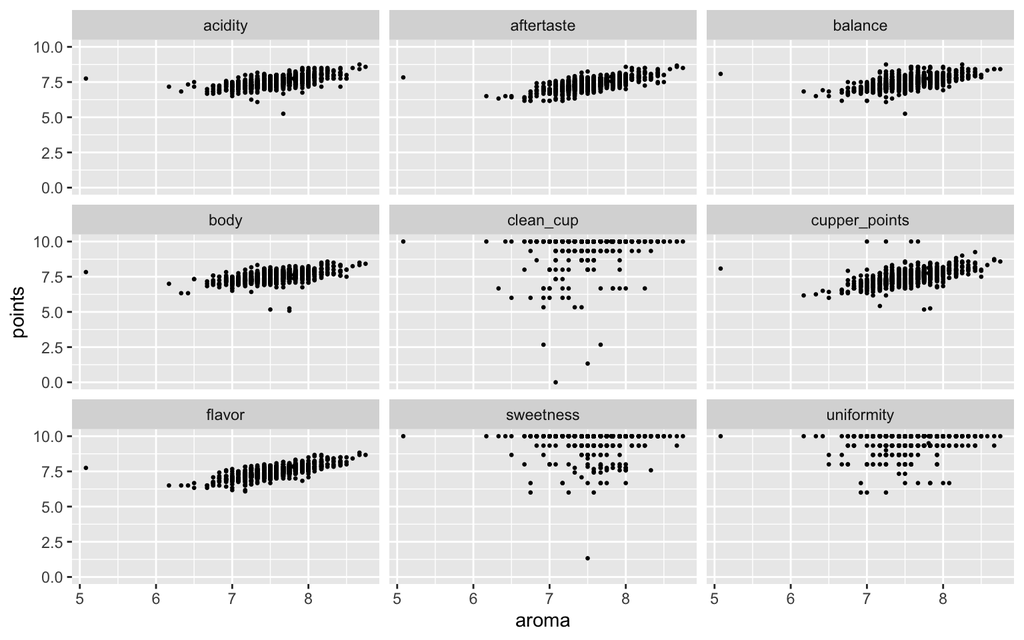

In order to create this plot, you actually need to pivot TWICE:

- First, use `pivot_wider()` just as you did in question 3.4 (hint! you should have used that function in 3.4!)
- Then, use `pivot_longer()` to long-pivot *all point columns EXCEPT FOR `aroma`*. The data you end up plotting should be structured like this.

  ```
  ## # A tibble: 12,042 x 4
  ##    unique_coffee aroma points_category points
  ##            <int> <dbl> <chr>            <dbl>
  ##  1             1  8.67 flavor            8.83
  ##  2             1  8.67 aftertaste        8.67
  ##  3             1  8.67 acidity           8.75
  ##  4             1  8.67 body              8.5
  ##  5             1  8.67 balance           8.42
  ##  6             1  8.67 uniformity       10
  ##  7             1  8.67 clean_cup        10
  ##  8             1  8.67 sweetness        10
  ##  9             1  8.67 cupper_points     8.75
  ## 10             2  8.75 flavor            8.67
  ## # … with 12,032 more rows
  ```

- You can then make your plot faceted by `points_category`.
- **FOR BONUS POINTS:** Ensure there are cleaned *panel labels* (also referred to as “strip labels”) in your final plot that do not contain underscores. These panel labels automatically use the values from the data, so you’d want to find a way to change these in the data before plotting. Or, enjoy a `ggplot2` documentation adventure and learn other fancier ways to modify the strip labels.